# Housing Request

2022-04-04

## Finding housing based on criteria using statistics

#### Installing packages and downloading data

The following code will install the respective packages for analysis and visualization and download the data from a GitHub for the variable assignment.

```r
library(mosaic)
library(tidyverse)
library(pander)
library(DT)
library(ggrepel)


Rent <- read_csv("https://raw.githubusercontent.com/ajaverett/data/main/Rent.csv")
```

#### Background

Stephanie is a student that will be starting school at BYU-Idaho next semester. Suppose she sent you the following email.

“Hi. My name is Stephanie. I would like to learn about what housing options I have for living at BYU-Idaho next semester. It will be my first semester there, so I would like to find something that is close to campus and around $300 a month in rent. I’m not too picky on roommates, but I would like somewhere that has a lot of people around so I can get to know as many people as possible. Thanks in advance!”

#### Response

Dear Stephanie,

I ran an analysis based on your criteria to determine the most suitable apartments for you to live in. The criteria I analyzed among the female dorms were the following:

```r
rent2 <- Rent %>%
  mutate(Per_month = round(Price/3.5,2)) %>%
  filter(Per_month <= 320 & Per_month >= 280) %>%
  filter(Capacity >= 150) %>%
  filter(WalkingMinutes < 6) %>%
  filter(Gender == 'F')
```

#### Analysis

Because there are three variables to analyze, I made two scatter plots that focus on price with either campus distance and capacity. By using this design, Stephanie can decide which variable is most important to her.

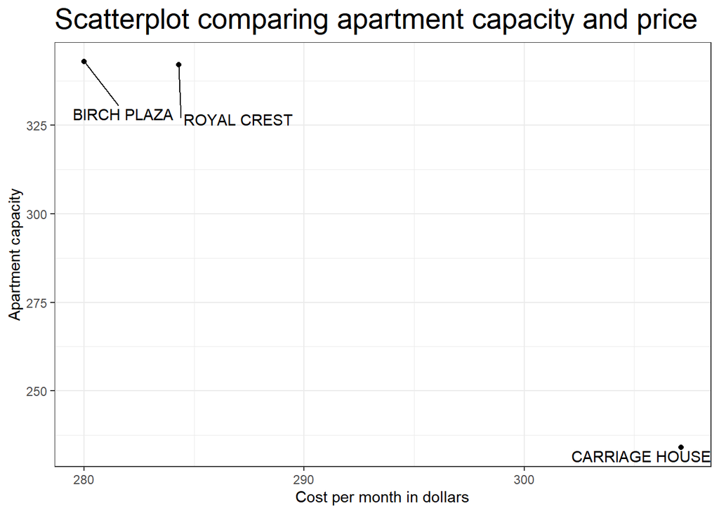

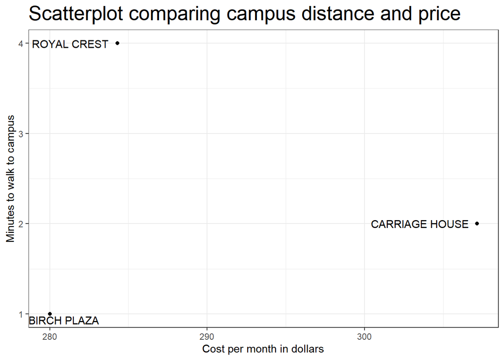

```r
rent2 %>%
  ggplot(mapping = (aes(x = Per_month, y = Capacity, label = Apartment))) +
    geom_point() +
    geom_text_repel(
      hjust = "inward",
      force_pull = 40,
      nudge_y = -15
      ) +
    theme_bw() +
    labs(y = "Apartment capacity", x = "Cost per month in dollars")  +
    ggtitle('Scatterplot comparing apartment capacity and price') +
  theme(plot.title = element_text(size = 20))

rent2 %>%
  ggplot(mapping = (aes(x = Per_month, y = WalkingMinutes, label = Apartment))) +
    geom_point() +
    geom_text_repel(hjust = "left"
      #hjust = 35, vjust = 0
      ) +
    theme_bw() +
    labs(y = "Minutes to walk to campus", x = "Cost per month in dollars") +
    ggtitle('Scatterplot comparing campus distance and price') +
  theme(plot.title = element_text(size = 20))
```

#### Weighing options

The second visualization weighs apartment to campus travel time and cost per month in dollars. Analyzing the three points, we learn certain things. For example, since Stephanie is prioritizing low cost (while still in the $300 range) and low walking time, the bottom left area of the graph is where points of apartments that best fulfill her requests would be. Because of this, Birch Plaza matches the best. Royal Crest and Carriage House also has relatively low walk time, but is beaten by Birch Plaza.

#### Conclusion

Because of this, while ultimately the decision of Stephanie, we personally recommend Birch Plaza. Other options worth considering include, Carriage House or Royal Crest

```r
datatable(rent2, options = list(lengthMenu = c(3,10,30)), extensions = "Responsive")
```

|  | Apartment | Gender | Address | Phone | Price | PrivateRoomPrice | Capacity | ParkingStalls | Deposit | UtilityDeposit | FloorPlans | Website | Latitude | Longitude | MilesToCampus | WalkingMinutes | Description | Per_month |
| --- | --- | --- | --- | --- | --- | --- | --- | --- | --- | --- | --- | --- | --- | --- | --- | --- | --- | --- |
| 1 | BIRCH PLAZA | F | 236 S 1ST W | (208) 359-8200 | 980 | 980 | 343 | 160 | 75 | 0 | 1 | www.rexburghousing.com | 43.8209717 | -111.7867163 | 0.062137274 | 1 | Some girls choose to spend all of their BYU-Idaho years living at Birch Plaza. That's how good it is. The wards are outstanding, and there's a sense of community that you'll find almost nowhere else. … | 280 |
| 2 | CARRIAGE HOUSE | F | 246 S 1ST W | 208-356-4361 | 1075 | 1075 | 234 | 85 | 125 | 0 | 1 | www.bestnesthousing.com/carriage-house.php | 43.8207848 | -111.7867195 | 0.062137274 | 2 | Free washer/dryer in every apt! $50 RM and military discounts. $50 discount for returning tenants. No limit on our discounts! 100% refundable security deposit. Utilities included. No application fees.… | 307.14 |
| 3 | ROYAL CREST | F | 340 S 1ST W | 208-356-7778 | 995 | 995 | 342 | 0 | 75 | 0 | 3 | WWW.ROYALCRESTAPARTMENTS.COM | 43.8191657 | -111.7869267 | 0.186411821 | 4 | If you are looking for affordable, comfortable, social living then Royal Crest is the place for you this semester. With our convenient location in Rexburg, you can be sure to be close to all the commu… | 284.29 |